# MY472: Mid-Term Problem Set Solutions

LSE Candidate Number: 43260

Autumn Term 2024

## Excercise 3

### PART 1

In the judges dataset, each row appears to represent a single judge, with multiple variables stored in the columns, such as their court type (e.g., U.S. Court of Appeals) and appointment title. To verify this more formally, I checked whether each judge ID in the nid column is unique and matches the total number of rows in the dataset. This test returned TRUE, indicating that each row represents a unique judge, which satisfies the tidy data principle that each row corresponds to a distinct observation.

Secondly, this tabular dataset is tidy because all variables are represented as columns, and no variables are stored in rows or combined within a single column. Upon inspecting the column names and structure, I confirmed that no columns mix multiple variables. For example, if a judge has multiple appointments, these are represented in distinct columns (e.g., appointment title (1) and appointment title (2)), rather than being concatenated into a single column.

Hence, because each row uniquely represents a judge, with all variables in separate columns and none stored in rows or combined, this dataset can be considered tidy.

### PART 2

In this part, I transform the dataset into a long format, where each row corresponds to a specific appointment, in order analyse appointments on a row-by-row basis more effectively.

I used the pivot_longer function to convert the data from a wide format, where each appointment had its own column, into a long format, where each row represents a specific appointment for a judge.

Next, I identified the relevant columns starting with “Court Type” (e.g., Court Type (1), Court Type (2)), which correspond to different judicial appointments. Using pivot_longer(), I created two new columns: appointment_number for the appointment number and court_type for the court type of each appointment.

To clean the data, I used mutate() with parse_number() to extract the numeric part of the appointment labels, then removed rows with missing court_type values, as not all judges were appointed 4 times, which is the maximum number of appointments observed for any judge. Finally, I printed the first five rows of the reshaped dataset to verify the transformation.

These steps resulted in a long-format dataset where each row corresponds to a unique judicial appointment, making it easier to analyze how many appointments each judge has had.

As a robustness check, I verify that the amount of unique values in the judge ID column (nid) match the rows in the original dataset (n=4008), which confirms this.

```
## # A tibble: 4,704 × 197
##        nid      jid `Last Name` `First Name` `Middle Name` Suffix `Birth Month`
##      <dbl>    <dbl> <chr>       <chr>        <chr>         <chr>          <dbl>
## 1 13761857 13761857 Abelson     Adam         Ben           <NA>              NA
## 2  1393931     3419 Abrams      Ronnie       <NA>          <NA>              NA
## 3  1376976        1 Abruzzo     Matthew      T.            <NA>               4
## 4 13651551 13651551 Abudu       Nancy        Gbana         <NA>              NA
## 5  1376981        2 Acheson     Marcus       Wilson        <NA>               6
## # ℹ 4,699 more rows
## # ℹ 190 more variables: `Birth Day` <dbl>, `Birth Year` <dbl>,
## #   `Birth City` <chr>, `Birth State` <chr>, `Death Month` <dbl>,
## #   `Death Day` <dbl>, `Death Year` <dbl>, `Death City` <chr>,
## #   `Death State` <chr>, Gender <chr>, `Race or Ethnicity` <chr>,
## #   `Court Name (1)` <chr>, `Appointment Title (1)` <chr>,
## #   `Appointing President (1)` <chr>, …
```

I now create another tibble arranged to show how many judge appointments each person in this dataset had. The dataset is arranged in descending order for the number of appointments.

I start by grouping the long data by unique judge ID using the group_by() function. Next, I count the number of appointments for each judge using the summarise() function and n(), which returns the number of rows (appointments) for each group. This count is stored in a new column called n_appointments. I then arrange this column in descending order and calculate the mean and median number of appointments

```
## # A tibble: 4,008 × 2
##       nid n_appointments
##     <dbl>          <int>
## 1 1378736              4
## 2 1381666              4
## 3 1382066              4
## 4 1382256              4
## 5 1382561              4
## # ℹ 4,003 more rows
```

From this tibble, we observe that the maximum amount of appointment for any single judge was 4 appointments, this was achieved by 12 judges in total. On average, the judges in our data were appointed 1.17 times and the median number of appointments is 1. This suggests that most judges were appointed only once, while a small group had multiple appointments, with few judges reaching as many as 4 appointments.

### PART 3

**Data Formatting**

In order to create a visualisation for the number of actively serving judges by year, specifically for those actively serving on the 1st of January of each year. I choose to structure my data as follows. I utilise the long format of my dataset previously created in which each row represent a single appointment. I then create unique commission date and termination dates variables for each appointment. If not, these variables were instead distributed throughout various columns (Commission Date (1) through to (4)). This was done by using the Commission Date (1) as the date if it was a judge’s first appointment, (2) for the second appointment, and so on.

Next, I created a sequence of dates from January 1, 1790, to January 1, 2024, using seq(), generating a dates vector representing each year. Then, I used this vector to create a new tibble (active_judges) with one row for each date. I applied the rowwise() function to calculate the number of active judges for each date, using mutate() to create a column with the number of actively serving judges for each date (rnum_active_judges column).

I considered a judge actively serving for each date if their commission dates are on or before the current date, and whose termination dates are later than the current date, or missing, indicating that a judge is still actively serving.

Our data now contains dates for the first of January for each year from 1790 to 2024 and the corresponding number of actively serving judges for each year and I now proceed to the visualisation.

**Data Visualisation**

I created the line plot visualisation below using ggplot2 to visualise the number of actively serving federal judges on January 1st each year from 1790 to 2024. I used geom_line with a steel blue color and adjusted the line width for clarity. The x-axis displays years with major ticks every 10 years, ranging from 1790 to 2030. For the y-axis, I set the range from 0 to 1500 judges, with breaks every 300 judges. I added a centered title and subtitle, used a minimal theme, and rotated the x-axis labels for readability. It must be noted that the code I used to rotate the date labels slightly vertically for readability was obtained with ChatGPT.

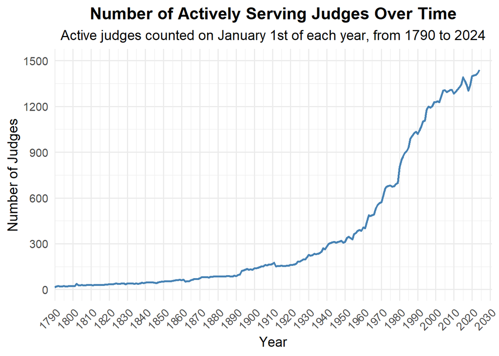

From this visualisation, we observe that the number of active serving judges remained quite constant between 1790 and 1890, remaining under 150. These then start to pick up progressively in the stage 1900 to 1950, before growing at a far greater rate, going from 300 serving judges in 1950 to just under 1500 at the end of our data timespan in 2024.

### PART 4

I first subset the judges data to contain only relevant rows for practicality. I then concatenate ‘Last Name’, ‘First Name’, and ‘Middle Name’ into a single ‘name’ column. Next, I subset the data to contain only the judges whose first appointment (indicated by the ’Commission Date (1) variable) was on or after the 1st January 1970 and before 1st January 2024, which I obtain by setting a date class to “1970-01-01” and “2024-01-01” and filtering for the first appointment date if equal or superior to the former and inferior to the latter.

Subsetting to the judges whose first appointment was on or after 1st January 1970 and before 1st January 2024, takes our total number of judges in the data from 4008 to 2349.

```
## # A tibble: 2,349 × 3
##       nid name                   `Professional Career`
##     <dbl> <chr>                  <chr>
## 1 1376986 William Marsh Acker    U.S. Army private first class, 1946-1947; Priv…
## 2 1376991 Harold Arnold Ackerman Private practice, New Jersey, 1951-1954; Judge…
## 3 1376996 James Waldo Ackerman   Private practice, Sangamon County, Illinois, 1…
## 4 1377001 Raymond L. Acosta      Private practice, Hackensack, New Jersey, 1953…
## 5 1377031 Henry Lee Adams        Reginald Heber Smith Fellow, Duval County Lega…
## # ℹ 2,344 more rows
```

In order to analyse the prior careers of the judges in the data, some manipulation to the ‘Professional Career’ is needed. I first identify the maximum amount of careers for any one judge, which I find to be 20. I then create the columns Career_1 through to Career_20 for each judge, splitting the character by the use of semicolons with the strsplit function and the columns with NAs for the judges who didn’t have as many prior careers. I then calculate the number of prior jobs for each jusge using rowsums and excluding NAs. I then calculate the mean, median and max number of prior careers for all judges in the remaining dataset.

On average, judges whose first appointment was on or after 1st January 1970 and before 1st January 2024 had 5.23 prior jobs to taking office. Whilst their median amount of jobs prior to taking office was 5. The judge with the most prior jobs is Gary S. Katzmann with a total of 20 prior jobs.

## Appendix: All code in this assignment

```r
# this chunk contains code that sets global options for the entire .Rmd.
# we use include=FALSE to suppress it from the top of the document, but it will still appear in the appendix.

knitr::opts_chunk$set(echo = FALSE) # actually set the global chunk options.
# we set echo=FALSE to suppress code such that it by default does not appear throughout the document.
# note: this is different from .Rmd default

#PART 1 CODE

bio.file.path <- "C:/Users/Lucca/Local/my472-at24-ps2-luccarallovander/ex3/judges.csv"

library(tidyverse)
judges <- read_csv(bio.file.path)

head(judges)

#inspecting dataset structure and colnames
glimpse(judges)
colnames(judges)

# Check if the number of unique IDs matches the number of rows
n_distinct(judges$nid) == nrow(judges)
#Returns True.





#PART 2 CODE

# Load the tidyverse library
library(tidyverse)

# Convert the dataset to long format
judges_long <- judges %>%
  pivot_longer(
    cols = starts_with("Court Type"),  # Select columns starting with "Court Type"
    names_to = "appointment_number",   # New column for appointment number
    values_to = "court_type"           # New column for the court type values
  ) %>%
  mutate(
    appointment_number = parse_number(appointment_number) # Extract the numeric part
  ) %>%
  filter(!is.na(court_type)) # Remove rows where court type is NA

#Robustness check
length(unique(judges_long$nid))
#returns 4008 same n as judges
# Print the first 5 rows
print(judges_long, n=5)
# Create a tibble showing the number of appointments per judge
judges_n_appointments <- judges_long %>%
  group_by(nid) %>%  # Group by judge ID
  summarise(n_appointments = n()) %>%  # Count the number of appointments
  arrange(desc(n_appointments))  # Sort in descending order of appointments

print(judges_n_appointments, n = 5)
# Calculate the mean and median number of appointments
mean_appointments <- mean(judges_n_appointments$n_appointments)
median_appointments <- median(judges_n_appointments$n_appointments)

# Display the results
mean_appointments
median_appointments





#PART 3 CODE

#I create a judges_long_2 tibble which contains a single Commission Date and Termination Date
#column for each appointment, instead of being distributed throughout the Comission Date (1) to (4) columns.

judges_long_2 <- judges_long %>%
  mutate(
    # Use case_when to assign CommissionDate based on appointment_number
    CommissionDate = case_when(
      appointment_number == 1 ~ `Commission Date (1)`,
      appointment_number == 2 ~ `Commission Date (2)`,
      appointment_number == 3 ~ `Commission Date (3)`,
      appointment_number == 4 ~ `Commission Date (4)`,

    ),
    # Use case_when to assign TerminationDate based on appointment_number
    TerminationDate = case_when(
      appointment_number == 1 ~ `Termination Date (1)`,
      appointment_number == 2 ~ `Termination Date (2)`,
      appointment_number == 3 ~ `Termination Date (3)`,
      appointment_number == 4 ~ `Termination Date (4)`

    )
  )


dates <- seq(as.Date("1790-01-01"), as.Date("2024-01-01"), by = "year")

active_judges <- tibble(date = dates) %>%
  rowwise() %>%
  mutate(
    num_active_judges = sum(
      !is.na(judges_long_2$CommissionDate) &  # Ensure CommissionDate is not NA
      judges_long_2$CommissionDate <= date &  # Check if CommissionDate is on or before the current date
      (is.na(judges_long_2$TerminationDate) | judges_long_2$TerminationDate > date),  # Check if TerminationDate is NA or after the current date
      na.rm = TRUE  # Ignore NA values
    )
  ) %>%
  ungroup()

library(ggplot2)

ggplot(active_judges, aes(x = date, y = num_active_judges)) +
  geom_line(color = "steelblue", linewidth = 1) +  # Updated to use `linewidth`
  scale_x_date(
    date_breaks = "10 years",  # Major ticks every 10 years
    date_labels = "%Y",  # Show years on the x-axis
    limits = c(as.Date("1790-01-01"), as.Date("2030-12-31")),  # Set x-axis range to 1790-2024
    expand = c(0, 0)  # Remove padding around the axis
  ) +
  scale_y_continuous(
    limits = c(0, 1500),  # Set y-axis range from 0 to 1500
    breaks = seq(0, 1500, by = 300)  # Set y-axis breaks every 100 judges
  ) +
  labs(
    title = "Number of Actively Serving Judges Over Time",
    subtitle = "Active judges counted on January 1st of each year, from 1790 to 2024",
    x = "Year",
    y = "Number of Judges"
  ) +
  theme_minimal(base_size = 14) +  # Minimal theme with larger base font
  theme(
    axis.text.x = element_text(angle = 45, hjust = 1),  # Rotate x-axis labels for clarity
    plot.title = element_text(face = "bold", hjust = 0.5),  # Center-align title
    plot.subtitle = element_text(hjust = 0.5)  # Center-align subtitle
  )






#PART 4 CODE

judges <- read_csv(bio.file.path)

library(dplyr)

# Create a subset with the desired columns
judges_subset <- judges %>%
  select(nid, `Last Name`, `First Name`, `Middle Name`, `Commission Date (1)`, `Professional Career`)

# Combine 'Last Name', 'First Name', and 'Middle Name' into a single 'name' column
judges_subset <- judges_subset %>%
  unite(name, `First Name`, `Middle Name`,`Last Name`,, sep = " ", remove = TRUE, na.rm = TRUE)


# Filter the data to include only judges with appointments between 1970-01-01 and 2024-01-01
judges_filtered <- judges_subset %>%
  filter(`Commission Date (1)` >= as.Date("1970-01-01") &
         `Commission Date (1)` < as.Date("2024-01-01"))%>%
  select(-`Commission Date (1)`)%>%
  arrange(nid)
print(judges_filtered, n=5)

# I First Calculate the maximum number of careers any judge has
max_careers <- max(sapply(strsplit(judges_filtered$`Professional Career`, ";"), length))

# Print the maximum number of careers
max_careers

# Split the 'Professional Career' column into separate columns with upto 20 career columns
#as this was identified as the maximum for any one judge
judges_careers  <- judges_filtered %>%
  separate(`Professional Career`, into = paste0("Career_", 1:20), sep = ";", extra = "drop", fill = "right")


# Count the number of non-NA values (i.e., number of careers) for each judge
judges_careers <- judges_careers %>%
  mutate(num_prior_jobs = rowSums(!is.na(select(., starts_with("Career_")))))

# Calculate the average, median, and maximum number of prior jobs
average_jobs <- mean(judges_careers$num_prior_jobs, na.rm = TRUE)
median_jobs <- median(judges_careers$num_prior_jobs, na.rm = TRUE)
max_jobs <- max(judges_careers$num_prior_jobs, na.rm = TRUE)

# Display the results
average_jobs
median_jobs
max_jobs #confirming this value

# Filter judges with the maximum number of prior jobs
judges_with_max_jobs <- judges_careers %>%
  filter(num_prior_jobs == 20)

# Display the result
judges_with_max_jobs
# this chunk generates the complete code appendix.
# eval=FALSE tells R not to run (``evaluate'') the code here (it was already run before).
```